# One-way ANOVA and chi-square examples

Allison Horst

11/20/2019

## One-way ANOVA

#### Make some mock data

```r
set.seed(1020)
df_aov <- data.frame(treatment = rep(c("A","B","C"), each = 20),
                     value = c(rnorm(mean = 5, sd = 1.3, n = 20),
                               rnorm(mean = 8, sd = 1.8, n = 20),
                               rnorm(mean = 6, sd = 1.5, n = 20)))
```

#### Explore data & check assumptions

Visual exploration:

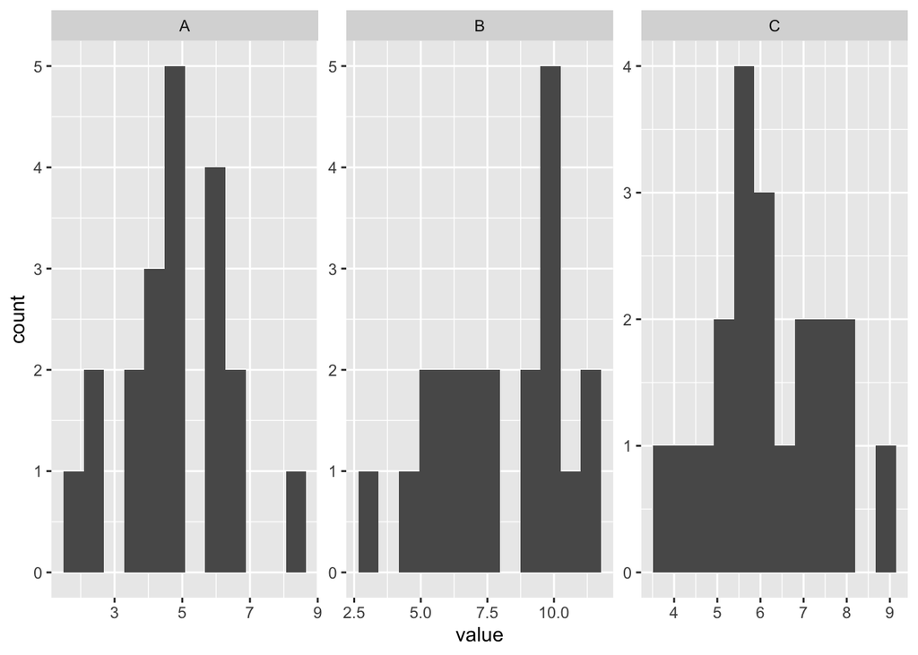

```r
ggplot(data = df_aov, aes(x = value)) +
  geom_histogram(bins = 12) +
  facet_wrap(~treatment, scales = "free")
```

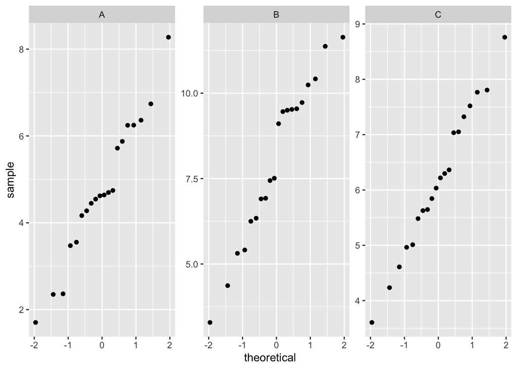

```r
ggplot(data = df_aov, aes(sample = value)) +
  geom_qq() +
  facet_wrap(~treatment, scales = "free")
```

```r
# Groups appear ~ normally distributed
# If large n, means to be normally distributed regardless of underlying population (CLT)
```

Check variances:

```r
# Create a summary table (including variances) by group
df_summary <- df_aov %>%
  group_by(treatment) %>%
  summarize(
    gp_mean = mean(value),
    gp_se = sd(value) / sqrt(n()),
    gp_var = var(value)
  )

df_summary # Largest variance (5.62), smallest variance (1.76)
```

```
## # A tibble: 3 x 4
##   treatment gp_mean gp_se gp_var
##   <fct>       <dbl> <dbl>  <dbl>
## 1 A            4.75 0.363   2.64
## 2 B            8.01 0.530   5.62
## 3 C            6.16 0.296   1.76
```

```r
# Levene's statistical test for equal variance:
leveneTest(value ~ treatment, data = df_aov) # There IS a significant difference
```

```
## Levene's Test for Homogeneity of Variance (center = median)
##       Df F value   Pr(>F)
## group  2  5.5331 0.006366 **
##       57
## ---
## Signif. codes:  0 '***' 0.001 '**' 0.01 '*' 0.05 '.' 0.1 ' ' 1
```

```r
# ...but, largest variance < 4x smallest variance
```

#### Run one-way ANOVA to compare group means

```r
my_aov <- aov(value ~ treatment, data = df_aov)
summary(my_aov)
```

```
##             Df Sum Sq Mean Sq F value Pr(>F)
## treatment    2  107.1   53.55   16.03  3e-06 ***
## Residuals   57  190.4    3.34
## ---
## Signif. codes:  0 '***' 0.001 '**' 0.01 '*' 0.05 '.' 0.1 ' ' 1
```

```r
# There IS a significant difference in means across groups. Which ones?

# Run post-hoc Tukey's:
my_post_hoc <- TukeyHSD(my_aov)
my_post_hoc
```

```
##   Tukey multiple comparisons of means
##     95% family-wise confidence level
##
## Fit: aov(formula = value ~ treatment, data = df_aov)
##
## $treatment
##          diff         lwr        upr     p adj
## B-A  3.262491  1.87150866  4.6534729 0.0000016
## C-A  1.407680  0.01669781  2.7986620 0.0467141
## C-B -1.854811 -3.24579296 -0.4638287 0.0061082
```

```r
# All pairwise combinations here are significantly different
```

#### Reporting outcomes of one-way ANOVA with post-hoc Tukey’s in text:

```r
# Getting the outputs from that ANOVA summary are a bit different.
# There are many ways to pull the information from a summary of your ANOVA.
# I find this way easiest.

# Outcomes of summary(my_aov) are stored in a list. Save the unlisted version:
aov_outputs <- unlist(summary(my_aov))

# Look at aov_outputs:
aov_outputs
```

```
##          Df1          Df2      Sum Sq1      Sum Sq2     Mean Sq1
## 2.000000e+00 5.700000e+01 1.071049e+02 1.904477e+02 5.355244e+01
##     Mean Sq2     F value1     F value2      Pr(>F)1      Pr(>F)2
## 3.341188e+00 1.602796e+01           NA 2.999456e-06           NA
```

```r
# The order that things appear in aov_outputs is the index number you'll reference to pull those pieces.
# Here are the pieces you'll need:

# The first item [1] is the numerator degrees of freedom;
# The second item [2] is the denominator degrees of freedom;
# The seventh item [7] is the F-statistic value;
# The ninth item [9] is the p-value
```

Pull those items as follows to create a statement of the ANOVA results (see Rmd for in-line referencing):

Mean phosphate concentration (mg/L) differed significantly across all three groups (one-way ANOVA with post-hoc Tukey’s HSD, F(2, 57) = 16.03, *p* = 0).

**Note:** In that case, you could just have p < 0.001 (since rounding will say p = 0).

**Note:** That is ONLY the statement of statistical outcomes. It should be accompanied by a more meaningful comparison of differences, e.g. by showing the groups visually or in a table with a measure of data spread/uncertainty, and by describing actual differences in text.

## Chi-square test for independence

#### Make a mock contingency table:

```r
# The counts of cats (top row) and dogs (bottom row) who choose pizza or burritos as their favorite food:

df_chi <- tribble(
  ~pizza, ~burrito,
  54, 30,
  40, 48
)

df_chi
```

```
## # A tibble: 2 x 2
##   pizza burrito
##   <dbl>   <dbl>
## 1    54      30
## 2    40      48
```

#### Chi-square test for independence

**We ask:** Does favorite food (pizza/burrito) differ significantly by species? Chi-square!

- See .Rmd for how to create the actual symbol here: ($\chi^2$)

Run the test:

```r
my_chi_test <- chisq.test(df_chi)
my_chi_test
```

```
##
##  Pearson's Chi-squared test with Yates' continuity correction
##
## data:  df_chi
## X-squared = 5.4129, df = 1, p-value = 0.01999
```

```r
# The chisq.test outputs are similar to the t.test outputs
# See the 'Value' section for ?chisq.test
```

#### Reporting the outcomes of chi-square in text (see Rmd for how to write this with in-line referencing):

There is a significant effect of species (cat/dog) on food preference (pizza/burrito) ($\chi$<sup>2</sup>(1) = 5.41, *p* = 0.02).

**Note:** This is only a statement of statistical results, and should be a piece of a more interesting and meaningful discussion about the actual proportions of cats and dogs choosing pizza vs. burritos.